# pca1

```python
import pandas as pd
import numpy as np
import matplotlib.pyplot as plt
```

### data processing and PCA

In this notebook we'll process the data and try to see what we can get from a simple principal component analysis in orderto see the tedencies in the data.

```python
crimes = pd.read_csv('./crime.csv', sep=',')
```

```python
crimes.head()
```

|  | id | State | Year | pop | Violent crime | murder | Robbery | Aggravated assault | Property crime | Burglary | rape | theft | rate |
| --- | --- | --- | --- | --- | --- | --- | --- | --- | --- | --- | --- | --- | --- |
| 0 | 9 | Connecticut | 2016.0 | 3576452.0 | 8123.0 | 78.0 | 2703.0 | 4579.0 | 64664.0 | 10045.0 | 1324.0 | 54619.0 | 0.790450 |
| 1 | 23 | Maine | 2016.0 | 1331479.0 | 1648.0 | 20.0 | 266.0 | 950.0 | 21912.0 | 4003.0 | 712.0 | 17909.0 | 0.256497 |
| 2 | 25 | Massachusetts | 2016.0 | 6811779.0 | 25677.0 | 134.0 | 5365.0 | 18050.0 | 106339.0 | 19193.0 | 3720.0 | 87146.0 | 1.436771 |
| 3 | 33 | New Hampshire | 2016.0 | 1334795.0 | 2637.0 | 17.0 | 427.0 | 1611.0 | 20194.0 | 2963.0 | 1005.0 | 17231.0 | 0.249276 |
| 4 | 44 | Rhode Island | 2016.0 | 1056426.0 | 2524.0 | 29.0 | 540.0 | 1513.0 | 20058.0 | 3788.0 | 770.0 | 16270.0 | 0.246068 |

```python
#crime = crime.drop(["rate","id"], axis = 1)
crimes.columns
```

```
Index(['id', 'State', 'Year', 'pop', 'Violent crime', 'murder', 'Robbery',
       'Aggravated assault', 'Property crime', 'Burglary', 'rape', 'theft',
       'rate'],
      dtype='object')
```

```python
crimes= crimes.reindex(columns=['State', 'id','Year', 'pop', 'Violent crime', 'murder', 'Robbery',
       'Aggravated assault', 'Property crime', 'Burglary', 'rape', 'theft',
       'rate'])
```

```python
crimes.head()
```

|  | State | id | Year | pop | Violent crime | murder | Robbery | Aggravated assault | Property crime | Burglary | rape | theft | rate |
| --- | --- | --- | --- | --- | --- | --- | --- | --- | --- | --- | --- | --- | --- |
| 0 | Connecticut | 9 | 2016.0 | 3576452.0 | 8123.0 | 78.0 | 2703.0 | 4579.0 | 64664.0 | 10045.0 | 1324.0 | 54619.0 | 0.790450 |
| 1 | Maine | 23 | 2016.0 | 1331479.0 | 1648.0 | 20.0 | 266.0 | 950.0 | 21912.0 | 4003.0 | 712.0 | 17909.0 | 0.256497 |
| 2 | Massachusetts | 25 | 2016.0 | 6811779.0 | 25677.0 | 134.0 | 5365.0 | 18050.0 | 106339.0 | 19193.0 | 3720.0 | 87146.0 | 1.436771 |
| 3 | New Hampshire | 33 | 2016.0 | 1334795.0 | 2637.0 | 17.0 | 427.0 | 1611.0 | 20194.0 | 2963.0 | 1005.0 | 17231.0 | 0.249276 |
| 4 | Rhode Island | 44 | 2016.0 | 1056426.0 | 2524.0 | 29.0 | 540.0 | 1513.0 | 20058.0 | 3788.0 | 770.0 | 16270.0 | 0.246068 |

```python
X = crimes.iloc[:, 1:].values
labels = crimes.iloc[:, 0].values
```

```python
X.shape
```

```
(51, 12)
```

```python
from sklearn import preprocessing

ss = preprocessing.StandardScaler().fit(X)
X_norm = ss.transform(X)
```

```python
from sklearn import decomposition

pca = decomposition.PCA(0.99)
pca.fit(X_norm)
```

```
PCA(n_components=0.99)
```

```python
print(pca.explained_variance_ratio_)
print(pca.explained_variance_ratio_.sum())
```

```
[0.87642834 0.08983862 0.01143381 0.009093   0.00654114]
0.9933349164224389
```

```python
pca.components_[0,:]
```

```
array([-4.53939805e-02,  2.22044605e-16,  3.17152969e-01,  3.19594593e-01,
        3.05268633e-01,  3.14621230e-01,  3.16514061e-01,  3.19633468e-01,
        3.14656866e-01,  3.10839129e-01,  3.19729934e-01,  3.20676437e-01])
```

```python
pca.components_[1,:]
```

```
array([ 9.95696905e-01,  7.28583860e-17,  4.79162639e-02, -1.43481245e-02,
        6.24820042e-02,  3.63456569e-04, -2.87452144e-02,  1.43080051e-02,
        1.21018350e-02,  2.61029910e-02,  1.47808634e-02,  1.02177841e-02])
```

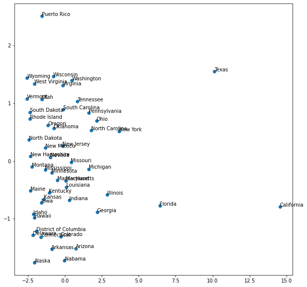

```python
import matplotlib
plt.rcParams["figure.figsize"] = (10,10)
X_pca = pca.transform(X_norm)
plt.scatter(X_pca[:, 0], X_pca[:, 1])
for label, x, y in zip(labels, X_pca[:, 0], X_pca[:, 1]):
    plt.annotate(label, xy=(x, y), xytext=(-0.2, 0.2), textcoords='offset points')
plt.show()
```

### Unemployment

```python
df = pd.read_csv('unemployment.csv')
df.head()
```

|  | id | state | county | rate |
| --- | --- | --- | --- | --- |
| 0 | 1001 | Alabama | Autauga County | 5.1 |
| 1 | 1003 | Alabama | Baldwin County | 4.9 |
| 2 | 1005 | Alabama | Barbour County | 8.6 |
| 3 | 1007 | Alabama | Bibb County | 6.2 |
| 4 | 1009 | Alabama | Blount County | 5.1 |

```python
df=df.drop(['id','county'], axis=1)
```

```python
df=df.groupby(["state"]).mean()
```

```python
df=df.reset_index()
```

```python
df.head(5)
```

|  | state | rate |
| --- | --- | --- |
| 0 | Alabama | 6.449254 |
| 1 | Alaska | 7.448276 |
| 2 | Arizona | 8.533333 |
| 3 | Arkansas | 4.496000 |
| 4 | California | 6.527586 |

```python
df.drop(df.index[df['state'] == 'Nebraska'], inplace = True)
```

```python
df=df.rename(columns = {"rate":"Unemployment_rate","state":"State"})
```

```python
df2= pd.merge(crimes, df, how='outer', on= 'State')
```

```python
df2.head(4)
```

|  | State | id | Year | pop | Violent crime | murder | Robbery | Aggravated assault | Property crime | Burglary | rape | theft | rate | Unemployment_rate |
| --- | --- | --- | --- | --- | --- | --- | --- | --- | --- | --- | --- | --- | --- | --- |
| 0 | Connecticut | 9 | 2016.0 | 3576452.0 | 8123.0 | 78.0 | 2703.0 | 4579.0 | 64664.0 | 10045.0 | 1324.0 | 54619.0 | 0.790450 | 5.362500 |
| 1 | Maine | 23 | 2016.0 | 1331479.0 | 1648.0 | 20.0 | 266.0 | 950.0 | 21912.0 | 4003.0 | 712.0 | 17909.0 | 0.256497 | 3.637500 |
| 2 | Massachusetts | 25 | 2016.0 | 6811779.0 | 25677.0 | 134.0 | 5365.0 | 18050.0 | 106339.0 | 19193.0 | 3720.0 | 87146.0 | 1.436771 | 3.642857 |
| 3 | New Hampshire | 33 | 2016.0 | 1334795.0 | 2637.0 | 17.0 | 427.0 | 1611.0 | 20194.0 | 2963.0 | 1005.0 | 17231.0 | 0.249276 | 2.830000 |

```python
X = df2.iloc[:, 1:].values
labels = df2.iloc[:, 0].values
```

```python
ss = preprocessing.StandardScaler().fit(X)
X_norm = ss.transform(X)
pca = decomposition.PCA(0.99)
pca.fit(X_norm)
print(pca.explained_variance_ratio_)
print(pca.explained_variance_ratio_.sum())
```

```
[0.8053813  0.09801874 0.0692896  0.00946362 0.00616916 0.00562902]
0.9939514403476367
```

```python
pca.components_[0,:]
```

```
array([-0.04430781, -0.        ,  0.31654771,  0.31909952,  0.30585743,
        0.31419136,  0.31602274,  0.31912374,  0.31429565,  0.31002821,
        0.31918685,  0.32016566,  0.05243097])
```

```python
pca.components_[1,:]
```

```
array([ 0.67148908,  0.        , -0.00611091, -0.02679606,  0.14741936,
       -0.01081924, -0.03477075, -0.01379407,  0.00289575, -0.04558621,
       -0.01769015, -0.01589927,  0.72280428])
```

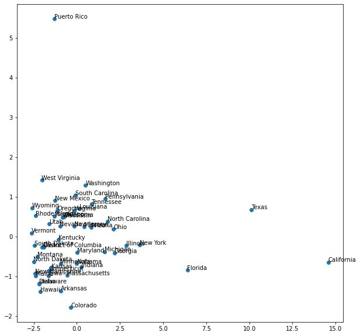

```python
import matplotlib
plt.rcParams["figure.figsize"] = (10,10)
X_pca = pca.transform(X_norm)
plt.scatter(X_pca[:, 0], X_pca[:, 1])
for label, x, y in zip(labels, X_pca[:, 0], X_pca[:, 1]):
    plt.annotate(label, xy=(x, y), xytext=(-0.2, 0.2), textcoords='offset points')
plt.show()
```

```python
df3 = df2[['rate', 'pop', 'Unemployment_rate']].copy()
import math
df3["rate"] = df3["rate"].apply(lambda x: math.floor(x*100)/100)
```

```python
df3.head(4)
```

|  | rate | pop | Unemployment_rate |
| --- | --- | --- | --- |
| 0 | 0.79 | 3576452.0 | 5.362500 |
| 1 | 0.25 | 1331479.0 | 3.637500 |
| 2 | 1.43 | 6811779.0 | 3.642857 |
| 3 | 0.24 | 1334795.0 | 2.830000 |

```python
X = df3.iloc[:, 1:].values
labels = df3.iloc[:, 0].values
```

```python
ss = preprocessing.StandardScaler().fit(X)
X_norm = ss.transform(X)
pca = decomposition.PCA(0.99)
pca.fit(X_norm)
print(pca.explained_variance_ratio_)
print(pca.explained_variance_ratio_.sum())
```

```
[0.55619436 0.44380564]
0.9999999999999999
```

### Interpretation des axes

```python
pca.components_[0,:]
```

```
array([0.70710678, 0.70710678])
```

#### Les points situés à droite dans cet axe ont une population et un taux de chomage élevé

```python
pca.components_[1,:]
```

```
array([-0.70710678,  0.70710678])
```

#### les points situés en haut ont une population basse ou un taux de chomage élevé

#### les points situés en bas ont une population élevée ou un taux de chomage bas

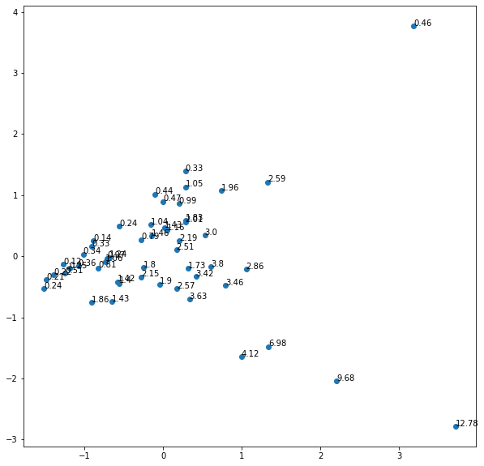

```python
import matplotlib
plt.rcParams["figure.figsize"] = (10,10)
X_pca = pca.transform(X_norm)
plt.scatter(X_pca[:, 0], X_pca[:, 1])
for label, x, y in zip(labels, X_pca[:, 0], X_pca[:, 1]):
    plt.annotate(label, xy=(x, y), xytext=(-0.2, 0.2), textcoords='offset points')
plt.show()
```

#### On remarque que pour les taux de criminalité très elevés ils sont plutôt situés en bas là où potentiellement la population est elevée ou le taux d'enemployment est bas, mais on remarque que lorsqu'on passe à droite le taux augmente davantage cela nous amène à conclure que le taux de criminalité est fortement lié à la population qu'au taux de chomage.

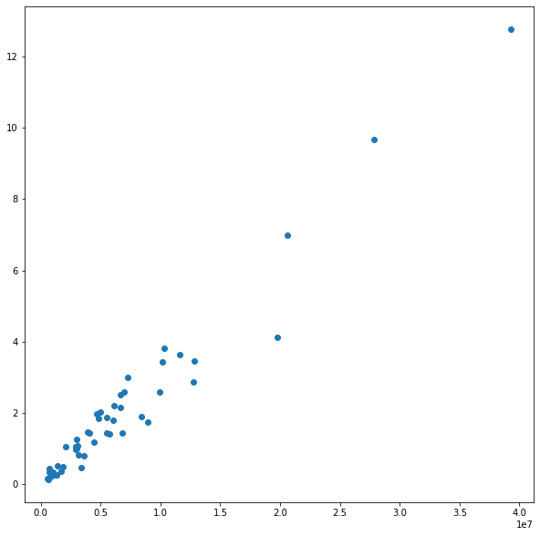

```python
plt.rcParams["figure.figsize"] = (10,10)
plt.scatter(df3['pop'],df3['rate'])
plt.show()
```

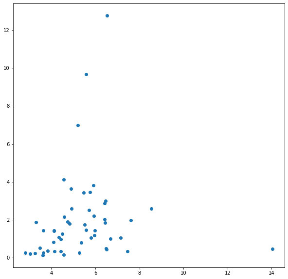

```python
plt.rcParams["figure.figsize"] = (10,10)
plt.scatter(df3['Unemployment_rate'],df3['rate'])
plt.show()
```

### PCA sur les states: gravité des crimes

```python
df4 = crimes.drop(['id','Year', 'pop', 'rate'], axis=1)
```

```python
df4.head(4)
```

|  | State | Violent crime | murder | Robbery | Aggravated assault | Property crime | Burglary | rape | theft |
| --- | --- | --- | --- | --- | --- | --- | --- | --- | --- |
| 0 | Connecticut | 8123.0 | 78.0 | 2703.0 | 4579.0 | 64664.0 | 10045.0 | 1324.0 | 54619.0 |
| 1 | Maine | 1648.0 | 20.0 | 266.0 | 950.0 | 21912.0 | 4003.0 | 712.0 | 17909.0 |
| 2 | Massachusetts | 25677.0 | 134.0 | 5365.0 | 18050.0 | 106339.0 | 19193.0 | 3720.0 | 87146.0 |
| 3 | New Hampshire | 2637.0 | 17.0 | 427.0 | 1611.0 | 20194.0 | 2963.0 | 1005.0 | 17231.0 |

```python
X = df4.iloc[:, 1:].values
labels = df4.iloc[:, 0].values
ss = preprocessing.StandardScaler().fit(X)
X_norm = ss.transform(X)
pca = decomposition.PCA(0.99)
pca.fit(X_norm)
print(pca.explained_variance_ratio_)
```

```
[0.95799587 0.01515377 0.0114573  0.00893534]
```

```python
1/(np.sqrt(8))
```

```
0.35355339059327373
```

```python
pca.components_[0,:]
```

```
array([0.35849704, 0.34361111, 0.35248137, 0.35523292, 0.35822724,
       0.35324033, 0.34866601, 0.35819584])
```

Il s'agit ici d'une sorte de moyenne sur les crimes, on peut interpréter cet axe comme le taux de criminalité d'un état

```python
pca.components_[1,:]
```

```
array([ 0.06977773,  0.78095138,  0.23690243,  0.04150121, -0.23828029,
       -0.22664192, -0.40193124, -0.24022514])
```

Dans cet axe, les états situés en haut auront des valeurs élevées de la crime 'Murder' et 'Robbery' et les états sitiés en bas auront des valeurs importantes des vols et des crimes de propriétés

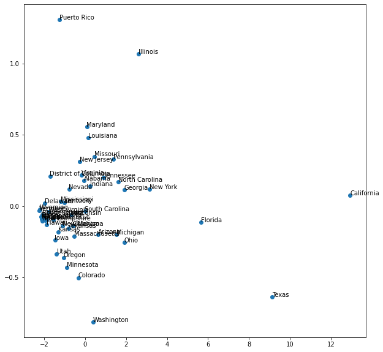

```python
plt.rcParams["figure.figsize"] = (10,10)
X_pca = pca.transform(X_norm)
plt.scatter(X_pca[:, 0], X_pca[:, 1])
for label, x, y in zip(labels, X_pca[:, 0], X_pca[:, 1]):
    plt.annotate(label, xy=(x, y), xytext=(-0.2, 0.2), textcoords='offset points')
plt.show()
```